# Laboratorio 2

daro

29/4/20

## AID

### Laboratorio 2

#### Consignas

##### 2. Crear una data frame tomando el archivo "alumnos_aid_2020.xlsx" con las columnas:

- Comision
- Titulo2
- Universidad2
- Genero
- Edad

```r
library(readxl)
library(here)
alumnos_AID_2020 <- read_excel(here("labs", "lab2","ds", "alumnos_aid_2020.xlsx"))
alumniDF <- data.frame(
  alumnos_AID_2020[, "Comision"],
  alumnos_AID_2020[, "Titulo2"],
  alumnos_AID_2020[, "Universidad2"],
  alumnos_AID_2020[, "Genero"],
  alumnos_AID_2020[, "Edad"],
  stringsAsFactors = TRUE
)
```

##### 3. Visualizar un histograma y un boxplot de la variable “Edad”. Discutir si corresponde a una distribución uniforme. Discutir qué conclusiones se pueden extraer de cada gráfico y en que situaciones utilizaría cada uno.

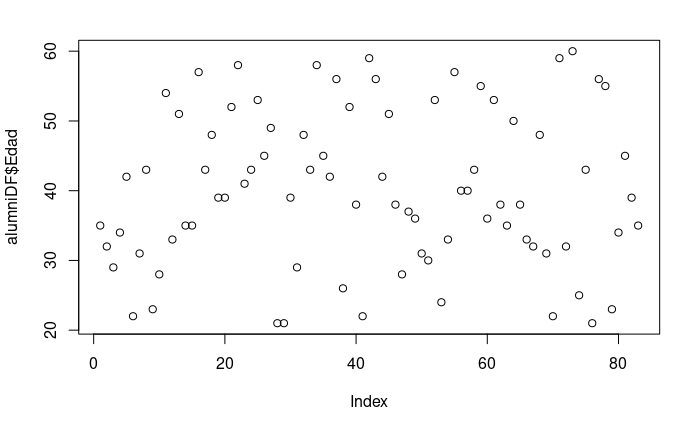

```r
plot(x = alumniDF$Edad)
```

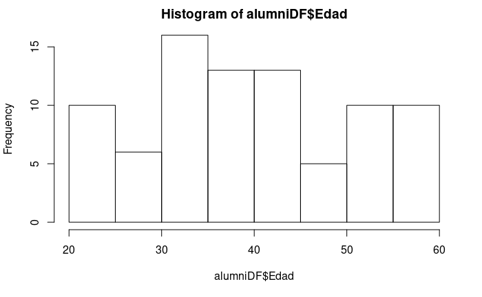

```r
hist(x= alumniDF$Edad)
```

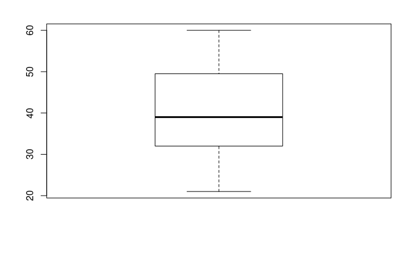

```r
boxplot(x= alumniDF$Edad)
```

##### 4.1. ¿Cuál es el título más frecuente de la maestría en 2020?

```r
freq_titulo <- as.data.frame(table(alumniDF$Titulo2))
titulo_mas_frecuente <- freq_titulo[which.max(freq_titulo$Freq),1]
```

##### 4.2. ¿Cuál es la universidad más frecuente de la maestría 2020?

```r
freq_univerdidad <- as.data.frame(table(alumniDF$Universidad2))
universidad_mas_frecuente <- freq_univerdidad[which.max(freq_univerdidad$Freq),1]
```

##### 5. Graficar en un “Barplot” los 4 títulos más frecuentes con sus respectivas cantidades de alumnos (ver gráfico del apunte teórico pag.28). Las barras deberán estar ordenadas de mayor a menor.

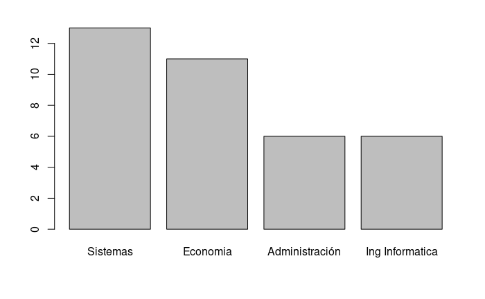

```r
titulos_top4 = freq_titulo[order(freq_titulo$Freq, decreasing=TRUE),][1:4,]
barplot(titulos_top4$Freq, names.arg = titulos_top4$Var1)
```

##### 6. Hallar una tabla que contenga las cantidades de alumnos de los 4 títulos más frecuentes, pero también informe las cantidades por cada género (tabla de doble entrada con 4x2 cantidades)

```r
alumniDF_top4 =  as.data.frame(filter(alumniDF, alumniDF$Titulo2 %in% titulos_top4[,1]))
```

[output not shown]

```r
freq_titulo_genero <- as.data.frame(table(alumniDF_top4$Genero, alumniDF_top4$Titulo2))
```

##### 7. Realizar un diagrama de barras superpuestas donde figuren las 4 carreras más frecuentes en el eje x, y aparte, sobre cada barra esté distinguido el género con 2 colores distintos (Idem gráfico del apunte teórico pag.29).

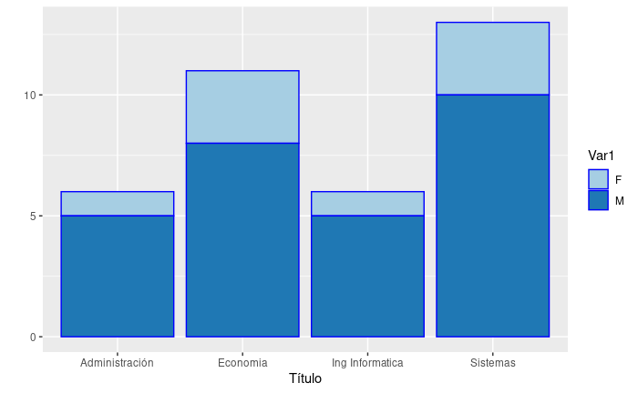

```r
library(ggplot2)
ggplot(data=freq_titulo_genero , aes( x=Var2 , y=Freq , fill =Var1 ) ) +
geom_bar (stat = "identity" , colour = "blue" ) +
scale_fill_brewer (palette = "Paired" ) +
xlab ( "Título" ) +
ylab ( "" )
```

##### 8. Dar una lista de los alumnos que estudiaron “Ing informática” y “Sistemas” de la comisión “C1” y que tengan 30 años o más

```r
alumniDF_sistemas <- subset(alumniDF, Titulo2 %in% c("Ing informática", " Sistemas") & Comision == 'C1')
```